# Time-Ordered Data

Reading Your Fits · Module 4

## A thousand samples ≠ a thousand pieces of evidence

- Fast logging, filters and slow dynamics link each reading to the one before.
- The residuals come in **runs** instead of scattering independently.
- The software doesn’t know; it counts every sample as fresh evidence.

## Runs in the residuals

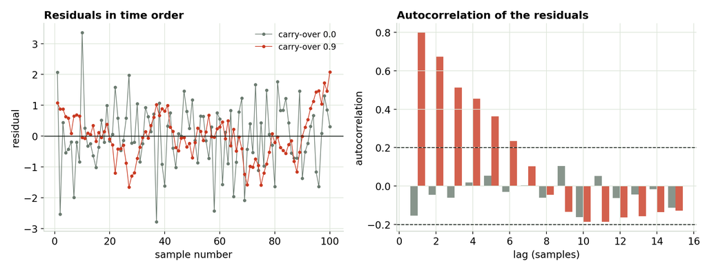

## What to check, and what to do

- Plot residuals **in run order**. Check lag-1 autocorrelation or **Durbin–Watson** (≈ 2 is fine, toward 0 is bad).
- **Fix the model first**: a missing drift term or time constant often causes it.
- For what’s left: **Newey–West (HAC)** standard errors, or treat whole runs as the units.

## The cooling-curve log trap

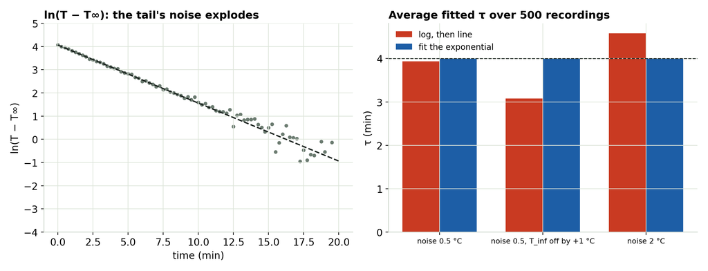

## Fit the exponential directly

- The log stretches the tail’s noise and drops points below T∞.
- Any error in T∞ bends the late tail and biases τ.
- Use `curve_fit` (Python), `fitnlm` (MATLAB) or Solver (Excel) on T itself. Same for damping: fit the damped sine, don’t lean on one log decrement.

## Count runs, not samples

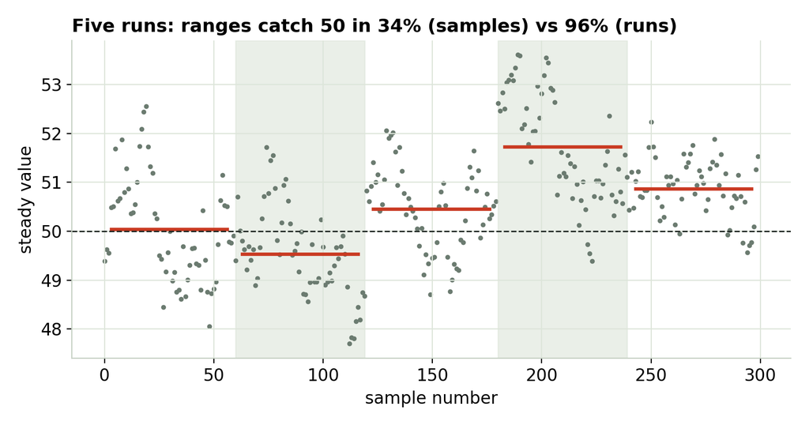

## Try it yourself

[interactive chart not shown]

The interactive loads from the page next to these slides. Open it in its own tab.

## What to take away

- **Plot residuals in time order.** Runs mean linked errors and too-narrow error bars.
- **Don’t log-linearize a decay.** Fit the exponential.
- **Count runs, not samples**, when runs differ. More runs shrink the range; more samples per run don’t.

Next: Module 5, the invisible bias.